# Preliminary report - Temperature and biodiversity influence community stability differently in birds and fishes

Shyamolina Ghosh, Blake Matthews, Owen Petchey

18 June, 2024

# 1 Data

## 1.1 Data structure

Total 1947 community timeseries we have collected for the timespan 1979-2019. 4 taxa are considered - birds, fish, freshwater invertebrates, terrestrial invertebrates. Below is the summary of the datatable. Description of each column is given in [README.txt](https://github.com/sghosh89/WP2/tree/main/Results)

```
## 'data.frame':    1947 obs. of  63 variables:
##  $ source                  : chr  "BioTIME" "BioTIME" "BioTIME" "BioTIME" ...
##  $ STUDY_ID                : chr  "57" "229" "229" "229" ...
##  $ newsite                 : chr  "57" "STUDY_ID_229_LAT35.04016_LON-83.36127" "STUDY_ID_229_LAT35.11187_LON-83.39091" "STUDY_ID_229_LAT35.14137_LON-83.29577" ...
##  $ REALM                   : chr  "Freshwater" "Freshwater" "Freshwater" "Freshwater" ...
##  $ TAXA                    : chr  "fish" "fish" "fish" "fish" ...
##  $ ORGANISMS               : chr  "fish" "fish" "fish" "fish" ...
##  $ initR                   : int  76 24 30 32 25 37 22 30 26 31 ...
##  $ nsp                     : int  34 14 11 17 14 16 13 11 14 10 ...
##  $ nyr_used                : int  32 23 20 21 21 23 23 20 20 28 ...
##  $ startyr                 : int  1981 1990 1990 1991 1990 1990 1990 1995 1995 1979 ...
##  $ endyr                   : int  2012 2013 2013 2012 2013 2013 2013 2014 2014 2006 ...
##  $ nint                    : int  561 91 55 136 91 120 78 55 91 45 ...
##  $ nind                    : int  503 59 35 97 61 91 67 46 60 36 ...
##  $ npos                    : int  35 29 20 27 29 27 11 7 26 7 ...
```

[output cut: 49 more lines]

# 2 Methods

## 2.1 Variables estimated and modelled

(Perhaps make this into a table.)

Let $n_{i,t,s}$ be the abundance (sometimes it was biomass data when abundance data were not available) of species $i$ at time $t$ at site $s$. Total abundance at time $t$ at site $s$ is $N_{t,s} = \sum_{i=1}^{s} n_{t,s,i}$.

*Community stability* at site $s$ was estimated as the inverse of the coefficient of temporal variation in total community abundance (when abundance info were not available, then biomass): $TempStab_s = 1 / CV(N_{t,s}) = abs(mean(N_{t,s})) / sd(N_{t,s})$

*Species richness* at site $s$ was estimated as the number of total species ($nsp$) and dominant species that were present minimum 70% of the total years sampled ($R$).

*Species evenness* at site $s$ was estimated as Smith-Wilson matrix.

*Community variance ratio*: a measure of synchrony, scaled between 0 to 1 ([Loreau & Mazancourt](https://www.journals.uchicago.edu/doi/10.1086/589746)).

*Community level total tail association from pairwise synchrony*: see [BioDyn project](https://doi.org/10.22541/au.169287307.74379399/v1), Figure 1.

*Temperature median*: Median of CHELSA-extracted annual temperature timeseries for the study years included in the analysis for each community.

*Temperature trend*: Monotonic trend of annual temperature timeseries (computed by non-parametric Sen’s method or parametric linear fit slope). I used the Sen’s slope in the path model, as non-parametric estimation has some advantage[, see wikipedia](https://en.wikipedia.org/wiki/Theil%E2%80%93Sen_estimator), but it is very similar to linear slope (see 2.1).

*Temperature skew*: Skewness of CHELSA-extracted annual temperature timeseries for the study years included in the analysis for each community.

*Temperature variability*: Temperature variability for the community during the study period = IQR(annual temperature distribution for the study period).

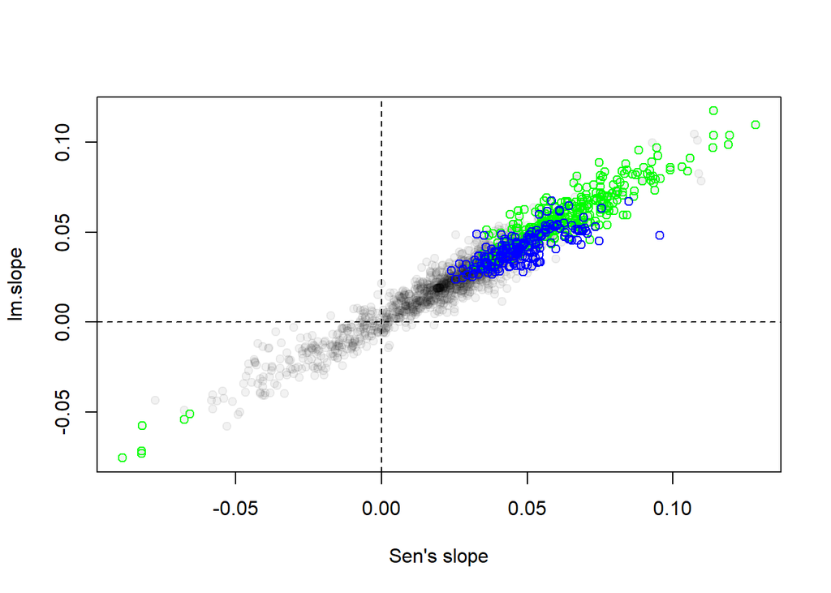

Figure 2.1: Distribution of temperature trend estimated by non-parametric Sen’s slope, and parametric linear fit slope. Colored points are significant Sen’s slope (green: birds, blue: fish).

# 3 Results

[figure not shown]

```
## ============ model summary for birds ===========
```

```
## # Check for Multicollinearity
##
## Low Correlation
##
##                  Term  VIF   VIF 95% CI Increased SE Tolerance Tolerance 95% CI
##                     R 1.88 [1.74, 2.05]         1.37      0.53     [0.49, 0.57]
##                     E 1.10 [1.05, 1.19]         1.05      0.91     [0.84, 0.95]
##                    VR 1.91 [1.77, 2.08]         1.38      0.52     [0.48, 0.57]
##                     A 2.15 [1.98, 2.35]         1.47      0.46     [0.43, 0.50]
##         t_med_celsius 1.14 [1.09, 1.23]         1.07      0.88     [0.81, 0.92]
##  t.sens.slope.celsius 1.07 [1.03, 1.17]         1.04      0.93     [0.85, 0.97]
##         t_skw_celsius 1.03 [1.00, 1.22]         1.01      0.97     [0.82, 1.00]
##      t_varIQR_celsius 1.11 [1.06, 1.20]         1.05      0.90     [0.83, 0.95]
```

```
##
##
## Structural Equation Model of psem_birds$model_psem
##
## Call:
##   A ~ R + E + VR + MedianT + VarT + TrendT + SkewT
##   VR ~ R + E + MedianT + VarT + TrendT
##   R ~ MedianT + VarT + TrendT
##   E ~ R + MedianT + VarT + TrendT
##   stability ~ R + E + VR + A + (R:MedianT) + MedianT + VarT + TrendT + SkewT
##
##     AIC
##  13982.614
##
## ---
## Tests of directed separation:
##
##     Independ.Claim Test.Type       DF Crit.Value P.Value
##    R ~ SkewT + ...      coef 1237.784     0.0534  0.8173
##    E ~ SkewT + ...      coef 1239.821     3.2520  0.0716
##   VR ~ SkewT + ...      coef  937.269     0.2742  0.6006
##
## --
## Global goodness-of-fit:
##
## Chi-Squared = NA with P-value = NA and on 3 degrees of freedom
## Fisher's C = 6.697 with P-value = 0.35 and on 6 degrees of freedom
##
## ---
## Coefficients:
##
##    Response Predictor Estimate Std.Error        DF Crit.Value P.Value
##           A         R   0.7455    0.0222  446.3098  1111.4656  0.0000
##           A         E   0.1624    0.0212  700.9222    57.8476  0.0000
##           A        VR   0.6063    0.0209 1184.5456   839.6357  0.0000
##           A   MedianT  -0.0085    0.0259  164.4514     0.1058  0.7454
##           A      VarT   0.0529    0.0233  700.1938     5.1095  0.0241
##           A    TrendT   0.0173    0.0237  300.5050     0.5238  0.4698
##           A     SkewT  -0.0512    0.0207  442.1973     6.0023  0.0147
##          VR         R  -0.3076    0.0321  832.6035    90.6595  0.0000
```

[output cut: 46 more lines]

```
##         0.0314
##         0.0116
##         0.0481
##
##   Signif. codes:  0 '***' 0.001 '**' 0.01 '*' 0.05
##
## ---
## Individual R-squared:
##
##    Response method Marginal Conditional
##           A   none     0.59        0.60
##          VR   none     0.15        0.32
##           R   none     0.00        0.65
##           E   none     0.03        0.57
##   stability   none     0.57        0.65
```

```
## ============ model summary for fish ===========
```

```
## # Check for Multicollinearity
##
## Low Correlation
##
##                  Term  VIF   VIF 95% CI Increased SE Tolerance Tolerance 95% CI
##                     R 3.00 [2.64, 3.44]         1.73      0.33     [0.29, 0.38]
##                     E 1.26 [1.16, 1.42]         1.12      0.79     [0.71, 0.86]
##                    VR 1.30 [1.19, 1.46]         1.14      0.77     [0.69, 0.84]
##                     A 2.42 [2.15, 2.76]         1.56      0.41     [0.36, 0.47]
##         t_med_celsius 1.44 [1.32, 1.62]         1.20      0.69     [0.62, 0.76]
##  t.sens.slope.celsius 1.15 [1.08, 1.30]         1.07      0.87     [0.77, 0.93]
##         t_skw_celsius 1.22 [1.13, 1.37]         1.11      0.82     [0.73, 0.88]
##      t_varIQR_celsius 1.43 [1.31, 1.61]         1.20      0.70     [0.62, 0.77]
```

```
##
##
## Structural Equation Model of psem_fish$model_psem
##
## Call:
##   A ~ R + E + VR + MedianT + VarT + TrendT + SkewT
##   VR ~ R + E + MedianT + VarT + TrendT
##   R ~ MedianT + VarT + TrendT
##   E ~ R + MedianT + VarT + TrendT
##   stability ~ R + E + VR + A + (R:MedianT) + MedianT + VarT + TrendT + SkewT
##
##     AIC
##  6146.839
##
## ---
## Tests of directed separation:
##
##     Independ.Claim Test.Type       DF Crit.Value P.Value
##    R ~ SkewT + ...      coef 456.9584     0.5157  0.4730
##    E ~ SkewT + ...      coef 306.8676     2.9680  0.0859
##   VR ~ SkewT + ...      coef 270.2988     2.9794  0.0855
##
## --
## Global goodness-of-fit:
##
## Chi-Squared = NA with P-value = NA and on 3 degrees of freedom
## Fisher's C = 11.325 with P-value = 0.079 and on 6 degrees of freedom
##
## ---
## Coefficients:
##
##    Response Predictor Estimate Std.Error       DF Crit.Value P.Value
##           A         R   1.0012    0.0328  62.9350   847.8942  0.0000
##           A         E   0.1136    0.0236 346.7961    22.4552  0.0000
##           A        VR   0.1119    0.0241 496.7346    21.1484  0.0000
##           A   MedianT  -0.0860    0.0299  56.9548     7.9227  0.0067
##           A      VarT   0.0346    0.0296 200.1121     1.3228  0.2515
##           A    TrendT   0.0148    0.0228 280.4936     0.4090  0.5230
##           A     SkewT  -0.0179    0.0273 175.9412     0.4189  0.5183
##          VR         R  -0.5555    0.0617 423.3584    79.4244  0.0000
```

[output cut: 46 more lines]

```
##        -0.0125
##        -0.1347   *
##        -0.0576
##
##   Signif. codes:  0 '***' 0.001 '**' 0.01 '*' 0.05
##
## ---
## Individual R-squared:
##
##    Response method Marginal Conditional
##           A   none     0.78        0.78
##          VR   none     0.39        0.50
##           R   none     0.15        0.55
##           E   none     0.27        0.44
##   stability   none     0.24        0.52
```

```
## ============ model summary for fish subset ===========
```

```
## # Check for Multicollinearity
##
## Low Correlation
##
##                  Term  VIF   VIF 95% CI Increased SE Tolerance Tolerance 95% CI
##                     R 3.14 [2.67, 3.75]         1.77      0.32     [0.27, 0.37]
##                     E 1.20 [1.10, 1.40]         1.09      0.83     [0.71, 0.91]
##                    VR 1.27 [1.15, 1.48]         1.13      0.79     [0.68, 0.87]
##                     A 2.51 [2.16, 2.98]         1.59      0.40     [0.34, 0.46]
##         t_med_celsius 1.53 [1.36, 1.78]         1.24      0.65     [0.56, 0.74]
##  t.sens.slope.celsius 1.17 [1.08, 1.38]         1.08      0.85     [0.73, 0.93]
##         t_skw_celsius 1.30 [1.17, 1.51]         1.14      0.77     [0.66, 0.85]
##      t_varIQR_celsius 1.64 [1.45, 1.91]         1.28      0.61     [0.52, 0.69]
```

```
##
##
## Structural Equation Model of psem_fish$model_psem
##
## Call:
##   A ~ R + E + VR + MedianT + VarT + TrendT + SkewT
##   VR ~ R + E + MedianT + VarT + TrendT
##   R ~ MedianT + VarT + TrendT
##   E ~ R + MedianT + VarT + TrendT
##   stability ~ R + E + VR + A + (R:MedianT) + MedianT + VarT + TrendT + SkewT
##
##     AIC
##  3842.186
##
## ---
## Tests of directed separation:
##
##     Independ.Claim Test.Type       DF Crit.Value P.Value
##    R ~ SkewT + ...      coef 218.4151     0.0025  0.9603
##    E ~ SkewT + ...      coef 222.4839     0.6325  0.4273
##   VR ~ SkewT + ...      coef 160.7222     1.9303  0.1666
##
## --
## Global goodness-of-fit:
##
## Chi-Squared = NA with P-value = NA and on 3 degrees of freedom
## Fisher's C = 5.366 with P-value = 0.498 and on 6 degrees of freedom
##
## ---
## Coefficients:
##
##    Response Predictor Estimate Std.Error       DF Crit.Value P.Value
##           A         R   0.9888    0.0393  17.6050   474.4369  0.0000
##           A         E   0.1051    0.0294 160.3627    11.9838  0.0007
##           A        VR   0.1186    0.0312 244.7211    13.6091  0.0003
##           A   MedianT  -0.0959    0.0369  36.1582     6.3364  0.0164
##           A      VarT   0.0487    0.0407  71.4778     1.3333  0.2521
##           A    TrendT  -0.0030    0.0303 202.4271     0.0096  0.9219
##           A     SkewT   0.0017    0.0366  86.5560     0.0021  0.9636
##          VR         R  -0.5611    0.0751 309.8607    54.4328  0.0000
```

[output cut: 46 more lines]

```
##         0.0034
##        -0.0873
##        -0.0743
##
##   Signif. codes:  0 '***' 0.001 '**' 0.01 '*' 0.05
##
## ---
## Individual R-squared:
##
##    Response method Marginal Conditional
##           A   none     0.77        0.77
##          VR   none     0.37        0.50
##           R   none     0.22        0.52
##           E   none     0.26        0.56
##   stability   none     0.22        0.64
```

```
## ============ model summary for birds ===========
```

```
## # Check for Multicollinearity
##
## Low Correlation
##
##                  Term  VIF   VIF 95% CI Increased SE Tolerance Tolerance 95% CI
##                     R 1.87 [1.73, 2.04]         1.37      0.53     [0.49, 0.58]
##                     E 1.10 [1.05, 1.19]         1.05      0.91     [0.84, 0.95]
##                    VR 1.91 [1.76, 2.08]         1.38      0.52     [0.48, 0.57]
##                     A 2.14 [1.97, 2.33]         1.46      0.47     [0.43, 0.51]
##         t_med_celsius 1.13 [1.08, 1.22]         1.06      0.88     [0.82, 0.93]
##  t.sens.slope.celsius 1.06 [1.02, 1.17]         1.03      0.95     [0.86, 0.98]
##        t_kurt_celsius 1.19 [1.13, 1.28]         1.09      0.84     [0.78, 0.89]
##      t_varIQR_celsius 1.30 [1.22, 1.40]         1.14      0.77     [0.71, 0.82]
```

```
##
##
## Structural Equation Model of psem_birds$model_psem
##
## Call:
##   A ~ R + E + VR + MedianT + VarT + TrendT + KurtT
##   VR ~ R + E + MedianT + VarT + TrendT
##   R ~ MedianT + VarT + TrendT
##   E ~ R + MedianT + VarT + TrendT + KurtT
##   stability ~ R + E + VR + A + (R:MedianT) + MedianT + VarT + TrendT + KurtT
##
##     AIC
##  13988.537
##
## ---
## Tests of directed separation:
##
##     Independ.Claim Test.Type       DF Crit.Value P.Value
##    R ~ KurtT + ...      coef 1229.173      0.334  0.5634
##   VR ~ KurtT + ...      coef 1074.700      0.048  0.8266
##
## --
## Global goodness-of-fit:
##
## Chi-Squared = NA with P-value = NA and on 2 degrees of freedom
## Fisher's C = 1.528 with P-value = 0.822 and on 4 degrees of freedom
##
## ---
## Coefficients:
##
##    Response Predictor Estimate Std.Error        DF Crit.Value P.Value
##           A         R   0.7490    0.0221  447.1684  1134.6897  0.0000
##           A         E   0.1627    0.0211  660.8626    58.5169  0.0000
##           A        VR   0.6054    0.0209 1182.3204   836.5760  0.0000
##           A   MedianT   0.0055    0.0253  163.1374     0.0471  0.8285
##           A      VarT   0.0655    0.0257  813.7156     6.4313  0.0114
##           A    TrendT   0.0117    0.0233  300.0538     0.2495  0.6178
##           A     KurtT   0.0172    0.0227  530.3014     0.5640  0.4530
##          VR         R  -0.3076    0.0321  832.6035    90.6595  0.0000
##          VR         E  -0.2165    0.0299 1060.2572    52.1107  0.0000
```

[output cut: 47 more lines]

```
##         0.0341
##         0.0189
##         0.0474
##
##   Signif. codes:  0 '***' 0.001 '**' 0.01 '*' 0.05
##
## ---
## Individual R-squared:
##
##    Response method Marginal Conditional
##           A   none     0.58        0.59
##          VR   none     0.15        0.32
##           R   none     0.00        0.65
##           E   none     0.03        0.58
##   stability   none     0.57        0.65
```

```
## ============ model summary for fish ===========
```

```
## # Check for Multicollinearity
##
## Low Correlation
##
##                  Term  VIF   VIF 95% CI Increased SE Tolerance Tolerance 95% CI
##                     R 3.24 [2.84, 3.72]         1.80      0.31     [0.27, 0.35]
##                     E 1.28 [1.18, 1.43]         1.13      0.78     [0.70, 0.85]
##                    VR 1.31 [1.21, 1.47]         1.15      0.76     [0.68, 0.83]
##                     A 2.59 [2.29, 2.97]         1.61      0.39     [0.34, 0.44]
##         t_med_celsius 1.48 [1.35, 1.67]         1.22      0.67     [0.60, 0.74]
##  t.sens.slope.celsius 1.15 [1.08, 1.30]         1.07      0.87     [0.77, 0.93]
##        t_kurt_celsius 1.29 [1.19, 1.45]         1.14      0.77     [0.69, 0.84]
##      t_varIQR_celsius 1.50 [1.36, 1.69]         1.23      0.67     [0.59, 0.73]
```

```
##
##
## Structural Equation Model of psem_fish$model_psem
##
## Call:
##   A ~ R + E + VR + MedianT + VarT + TrendT + KurtT
##   VR ~ R + E + MedianT + VarT + TrendT
##   R ~ MedianT + VarT + TrendT
##   E ~ R + MedianT + VarT + TrendT + KurtT
##   stability ~ R + E + VR + A + (R:MedianT) + MedianT + VarT + TrendT + KurtT
##
##     AIC
##  6048.136
##
## ---
## Tests of directed separation:
##
##     Independ.Claim Test.Type       DF Crit.Value P.Value
##    R ~ KurtT + ...      coef 474.4466     0.8827  0.3479
##   VR ~ KurtT + ...      coef 293.0998     4.3328  0.0383 *
##
## --
## Global goodness-of-fit:
##
## Chi-Squared = 78.585 with P-value = 0 and on 2 degrees of freedom
## Fisher's C = 8.639 with P-value = 0.071 and on 4 degrees of freedom
##
## ---
## Coefficients:
##
##    Response Predictor Estimate Std.Error       DF Crit.Value P.Value
##           A         R   1.0784    0.0353  93.1919   867.0076  0.0000
##           A         E   0.1208    0.0234 409.1075    25.9621  0.0000
##           A        VR   0.1204    0.0238 521.8463    25.3079  0.0000
##           A   MedianT  -0.1053    0.0307  56.0372    11.2763  0.0014
##           A      VarT   0.0147    0.0293 171.8530     0.2418  0.6236
##           A    TrendT   0.0198    0.0224 265.2202     0.7606  0.3839
##           A     KurtT   0.0111    0.0253 181.9446     0.1870  0.6659
##          VR         R  -0.5555    0.0617 423.3584    79.4244  0.0000
##          VR         E  -0.2990    0.0403 570.2196    54.5028  0.0000
```

[output cut: 47 more lines]

```
##        -0.0150
##         0.0898
##        -0.0948
##
##   Signif. codes:  0 '***' 0.001 '**' 0.01 '*' 0.05
##
## ---
## Individual R-squared:
##
##    Response method Marginal Conditional
##           A   none     0.80        0.81
##          VR   none     0.39        0.50
##           R   none     0.15        0.55
##           E   none     0.29        0.45
##   stability   none     0.25        0.49
```

```
## ============ model summary for fish subset ===========
```

```
## # Check for Multicollinearity
##
## Low Correlation
##
##                  Term  VIF   VIF 95% CI Increased SE Tolerance Tolerance 95% CI
##                     R 3.34 [2.83, 4.00]         1.83      0.30     [0.25, 0.35]
##                     E 1.21 [1.11, 1.42]         1.10      0.83     [0.70, 0.90]
##                    VR 1.28 [1.16, 1.49]         1.13      0.78     [0.67, 0.87]
##                     A 2.66 [2.28, 3.17]         1.63      0.38     [0.32, 0.44]
##         t_med_celsius 1.52 [1.35, 1.77]         1.23      0.66     [0.56, 0.74]
##  t.sens.slope.celsius 1.16 [1.07, 1.37]         1.08      0.86     [0.73, 0.94]
##        t_kurt_celsius 1.32 [1.19, 1.54]         1.15      0.76     [0.65, 0.84]
##      t_varIQR_celsius 1.70 [1.49, 1.99]         1.30      0.59     [0.50, 0.67]
```

```
##
##
## Structural Equation Model of psem_fish$model_psem
##
## Call:
##   A ~ R + E + VR + MedianT + VarT + TrendT + KurtT
##   VR ~ R + E + MedianT + VarT + TrendT
##   R ~ MedianT + VarT + TrendT
##   E ~ R + MedianT + VarT + TrendT + KurtT
##   stability ~ R + E + VR + A + (R:MedianT) + MedianT + VarT + TrendT + KurtT
##
##     AIC
##  3767.796
##
## ---
## Tests of directed separation:
##
##     Independ.Claim Test.Type       DF Crit.Value P.Value
##    R ~ KurtT + ...      coef 247.2314     2.0192  0.1566
##   VR ~ KurtT + ...      coef 182.3856     2.7137  0.1012
##
## --
## Global goodness-of-fit:
##
## Chi-Squared = 55.646 with P-value = 0 and on 2 degrees of freedom
## Fisher's C = 8.289 with P-value = 0.082 and on 4 degrees of freedom
##
## ---
## Coefficients:
##
##    Response Predictor Estimate Std.Error       DF Crit.Value P.Value
##           A         R   1.0407    0.0398  14.1819   503.7682  0.0000
##           A         E   0.1142    0.0287 142.3959    14.7831  0.0002
##           A        VR   0.1295    0.0307 228.4381    16.7192  0.0001
##           A   MedianT  -0.1120    0.0346  27.4854     9.7957  0.0041
##           A      VarT   0.0317    0.0374  40.9766     0.6483  0.4254
##           A    TrendT  -0.0095    0.0288 151.8061     0.1033  0.7484
##           A     KurtT  -0.0055    0.0321  71.2760     0.0274  0.8690
##          VR         R  -0.5611    0.0751 309.8607    54.4328  0.0000
##          VR         E  -0.1754    0.0526 328.0494    10.9485  0.0010
```

[output cut: 47 more lines]

```
##        -0.0060
##        -0.0066
##        -0.0966
##
##   Signif. codes:  0 '***' 0.001 '**' 0.01 '*' 0.05
##
## ---
## Individual R-squared:
##
##    Response method Marginal Conditional
##           A   none     0.79        0.79
##          VR   none     0.37        0.50
##           R   none     0.22        0.52
##           E   none     0.28        0.57
##   stability   none     0.23        0.62
```